# 463_Project

Jonathan Connors and Daniel Windus

## Abstact

Immunization plays a crucial role in managing any disease. Countries whose medical care is better equipped to generate and administer immunizations can better manage illness. Here we examine the connection between a country’s immunization spending and its COVID-19 death rate during the pandemic. We use a linear regression model to look at two different types of immunization spending (Government and DAH) to determine if either of them are significant predictors of COVID-19 death rate. The correlation is examined for the death rate as well as the log of the death rate, revealing that both types of spending are significant. Failed assumptions indicate the need for more research, but the initial results predicate that wealthier countries consider prioritizing healthcare aid to lower income countries in order to minimize the impacts of diseases such as COVID-19.

## Introduction

During the COVID-19 pandemic, many countries struggled to provide for the medical needs of their people as the disease raged across the world. Hospitals were overwhelmed and citizens were dying. As the vaccines were released, some countries were equipped for their production and distribution and some were not. A country’s level of preparedness was potentially impacted by the amount that they spent on immunizations during the years leading up to COVID. In this report, we examine national data on COVID death rates and immunization spending in order to determine if there is an existing correlation between these two variables.

We look at two main types of immunization spending: Government spending and Development Assistance for Health. Government spending consists of the money a country’s own government spends on immunization for its healthcare systems. The Development Assistance for Health (DAH) is the amount of money a country receives from other countries and health organizations that is spent on immunization. The spending will be calculated per capita.

The COVID death rate is in deaths per 100,000 people. All data sets were obtained from [the GDB results tool](https://ghdx.healthdata.org/).

## Exploratory Data Analysis

To prepare our data, we combine three different datasets: COVID mortality, immunization spending, and country populations. The datasets contain information on 128 countries. The COVID mortality rates come as an average rate between 1 January, 2020, and 31 December, 2021. The immunization spending dataset include data from 2000 to 2017. The populations are listed from the same range of years. After splitting the spending into the two categories (Government and DHA) we take the spending for each year and divide it by the population for that year to create a new variable, immunization spending per capita. We then take the average spending per capita for each country over the range of years and use that average value as the variable we test with.

```r
COVIDmortality <- read.csv("COVIDmortality.CSV")
IMMUNEspending <- read.csv("IMMUNEspending.CSV")
POPULATIONS <- read.csv("POPULATIONS.csv")

colnames(POPULATIONS) <- gsub("X", "", colnames(POPULATIONS))

POPULATIONS <- pivot_longer(POPULATIONS, cols = starts_with("2"), names_to = "year", values_to = "population")

covid_deaths <- COVIDmortality %>%
  filter(measure_name == "covid_death_rate")

gov_immune_spending_tot <- IMMUNEspending %>%
  filter(component_activity == "Total", financing_source == "Government")

gov_test <- merge(gov_immune_spending_tot, covid_deaths, by="location_id")

gov_table <- gov_test %>%
  select(location_isocode, location_id, year, val, mean_value)

gov_table <- gov_table %>%
  rename(Country.Code = "location_isocode")

gov_table <- merge(gov_table, POPULATIONS, by=c("Country.Code", "year"))

gov_table <- gov_table %>%
  mutate("sp_pc" = val / population)

gov_table <- gov_table %>%
  group_by(Country.Code) %>%
  mutate(avg_sp_pc = mean(sp_pc))

gov_data <- gov_table %>%
  filter(year == "2000") %>%
  select(Country.Code, mean_value, avg_sp_pc)

assist_immune_spending_tot <- IMMUNEspending %>%
  filter(component_activity == "Total", financing_source == "Development Assistance for Health")

assist_test <- merge(assist_immune_spending_tot, covid_deaths, by="location_id")

assist_table <- assist_test %>%
  select(location_isocode, location_id, year, val, mean_value)

assist_table <- assist_table %>%
  rename(Country.Code = "location_isocode")

assist_table <- merge(assist_table, POPULATIONS, by=c("Country.Code", "year"))

assist_table <- assist_table %>%
  mutate("sp_pc" = val / population)

assist_table <- assist_table %>%
  group_by(Country.Code) %>%
  mutate(avg_sp_pc = mean(sp_pc))

assist_data <- assist_table %>%
  filter(year == "2000") %>%
  select(Country.Code, mean_value, avg_sp_pc)
```

Before testing, we want to examine any trends in the data. We plot each of the spending categories against the COVID death rate.

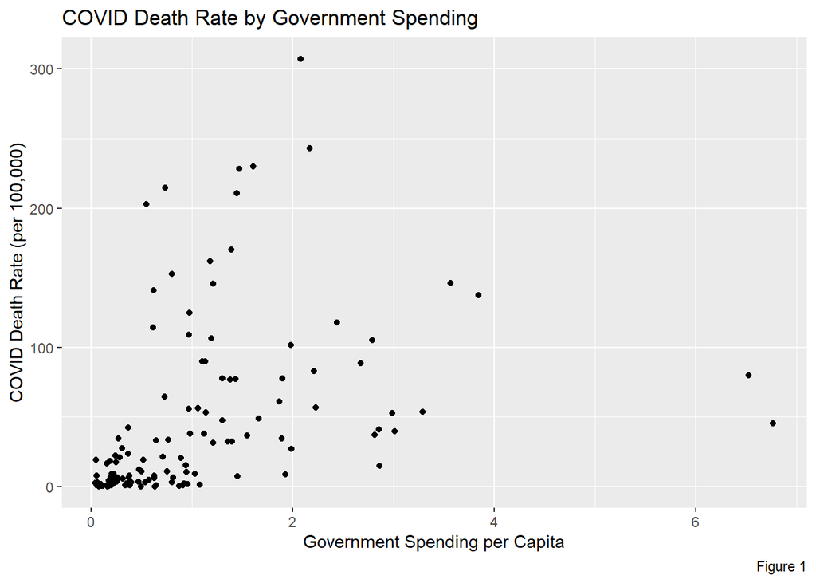

```r
ggplot(gov_data) +
  geom_point(aes(x = avg_sp_pc, y = mean_value)) +
  labs(x = "Government Spending per Capita",
       y = "COVID Death Rate (per 100,000)",
       caption = "Figure 1",
       title = "COVID Death Rate by Government Spending")
```

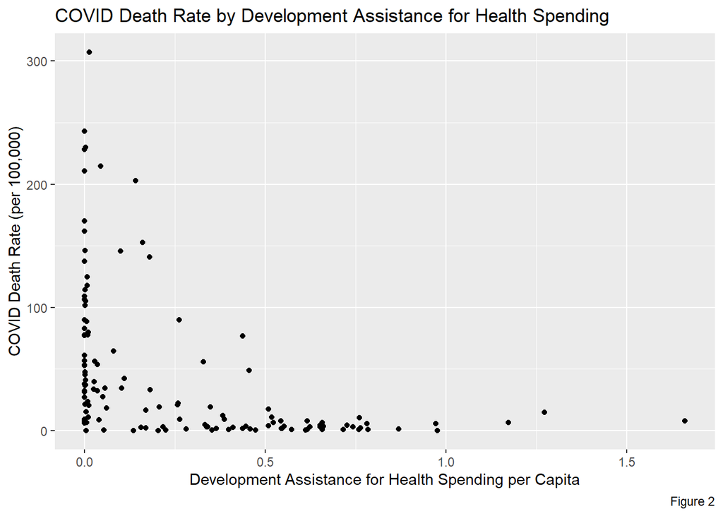

```r
ggplot(assist_data) +
  geom_point(aes(x = avg_sp_pc, y = mean_value)) +
  labs(x = "Development Assistance for Health Spending per Capita",
       y = "COVID Death Rate (per 100,000)",
       caption = "Figure 2",
       title = "COVID Death Rate by Development Assistance for Health Spending")
```

There do not appear to be strong trends. The graphs, particularly figure 2 also highlight a trend that many countries appear to have very low COVID death rates. This could be due to under-reporting, something that is discussed further in the conclusion.

## Statistical Data Analysis

To test this apparent correlation between the average COVID death rate and the average Government or Development Assistance for Health spending per person, we create two respective linear models.

```r
gov_linear<- lm(mean_value ~ avg_sp_pc, data = gov_data)
summary(gov_linear)
```

```
##
## Call:
## lm(formula = mean_value ~ avg_sp_pc, data = gov_data)
##
## Residuals:
##      Min       1Q   Median       3Q      Max
## -123.740  -28.532  -21.581    8.436  239.249
##
## Coefficients:
##             Estimate Std. Error t value Pr(>|t|)
## (Intercept)   23.109      7.001   3.301  0.00125 **
## avg_sp_pc     21.583      4.618   4.673  7.5e-06 ***
## ---
## Signif. codes:  0 '***' 0.001 '**' 0.01 '*' 0.05 '.' 0.1 ' ' 1
##
## Residual standard error: 57.64 on 126 degrees of freedom
## Multiple R-squared:  0.1477, Adjusted R-squared:  0.141
## F-statistic: 21.84 on 1 and 126 DF,  p-value: 7.497e-06
```

```r
assist_linear <- lm(mean_value ~ avg_sp_pc, data = assist_data)
summary(assist_linear)
```

```
##
## Call:
## lm(formula = mean_value ~ avg_sp_pc, data = assist_data)
##
## Residuals:
##    Min     1Q Median     3Q    Max
## -68.89 -33.80 -16.28  13.95 238.99
##
## Coefficients:
##             Estimate Std. Error t value Pr(>|t|)
## (Intercept)   69.380      6.399  10.842  < 2e-16 ***
## avg_sp_pc    -88.098     15.200  -5.796 5.14e-08 ***
## ---
## Signif. codes:  0 '***' 0.001 '**' 0.01 '*' 0.05 '.' 0.1 ' ' 1
##
## Residual standard error: 55.48 on 126 degrees of freedom
## Multiple R-squared:  0.2105, Adjusted R-squared:  0.2042
## F-statistic: 33.59 on 1 and 126 DF,  p-value: 5.136e-08
```

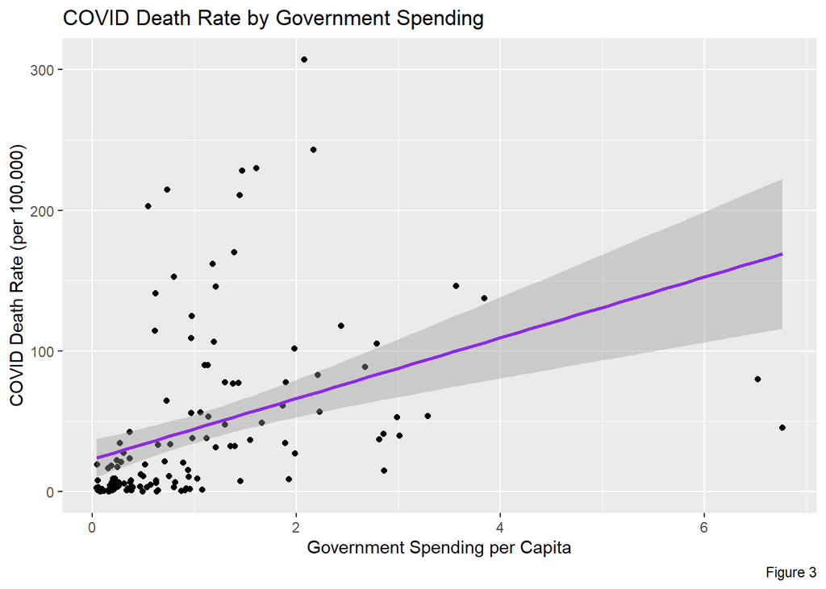

```r
ggplot(gov_data, aes(x = avg_sp_pc, y = mean_value)) +
  geom_point() +
  geom_smooth(method = "lm", color = "blueviolet") +
  labs(title = "COVID Death Rate by Government Spending",
       caption = "Figure 3",
       x = "Government Spending per Capita",
       y = "COVID Death Rate (per 100,000)")
```

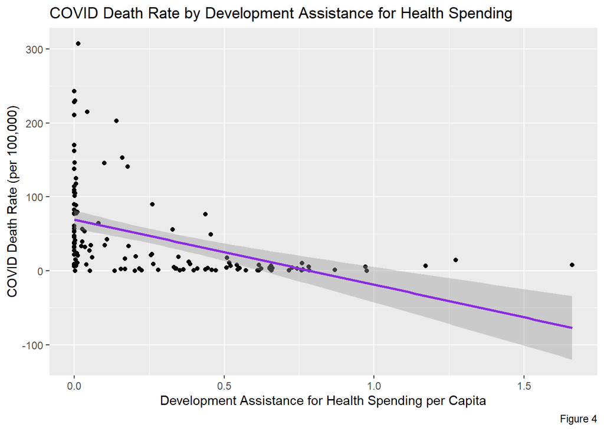

```r
ggplot(assist_data, aes(x = avg_sp_pc, y = mean_value)) +
  geom_point() +
  geom_smooth(method = "lm", color = "blueviolet") +
  labs(title = "COVID Death Rate by Development Assistance for Health Spending",
       caption = "Figure 4",
       x = "Development Assistance for Health Spending per Capita",
       y = "COVID Death Rate (per 100,000)")
```

However, these results come with a major caveat. The residuals for each model (shown below) are clearly not normally distributed, failing our modeling assumptions.

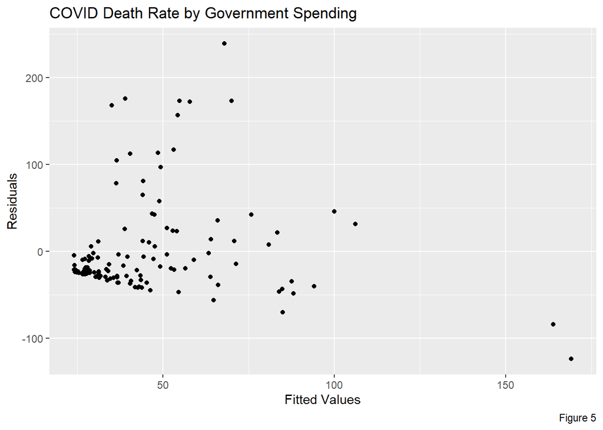

```r
ggplot(data = gov_linear) +
  geom_jitter(aes(y = .resid, x = .fitted)) +
  labs(title = "COVID Death Rate by Government Spending",
       caption = "Figure 5",
       x = "Fitted Values",
       y = "Residuals")
```

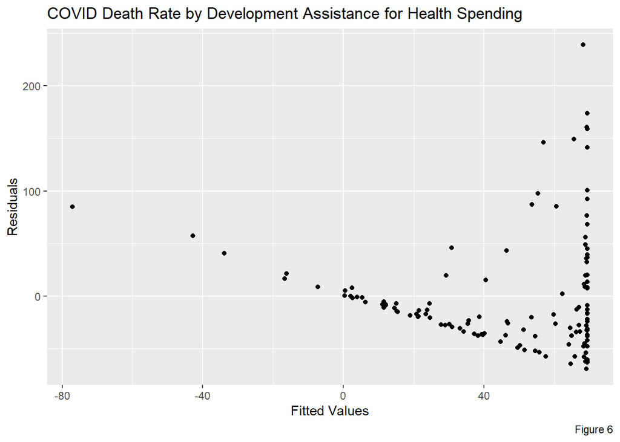

```r
ggplot(data = assist_linear) +
  geom_jitter(aes(y = .resid, x = .fitted)) +
  labs(title = "COVID Death Rate by Development Assistance for Health Spending",
       caption = "Figure 6",
       x = "Fitted Values",
       y = "Residuals")
```

So we now adjust our models. Instead of using average spending per person to model COVID death rates, we use the average spending per person to model the log of the COVID death rates.

```r
gov_log<- lm(log(mean_value) ~ avg_sp_pc, data = gov_data)
summary(gov_log)
```

```
##
## Call:
## lm(formula = log(mean_value) ~ avg_sp_pc, data = gov_data)
##
## Residuals:
##     Min      1Q  Median      3Q     Max
## -3.8566 -0.9445  0.1267  1.1627  3.1343
##
## Coefficients:
##             Estimate Std. Error t value Pr(>|t|)
## (Intercept)   1.7051     0.1985   8.592 2.79e-14 ***
## avg_sp_pc     0.8617     0.1309   6.582 1.13e-09 ***
## ---
## Signif. codes:  0 '***' 0.001 '**' 0.01 '*' 0.05 '.' 0.1 ' ' 1
##
## Residual standard error: 1.634 on 126 degrees of freedom
## Multiple R-squared:  0.2559, Adjusted R-squared:   0.25
## F-statistic: 43.32 on 1 and 126 DF,  p-value: 1.126e-09
```

```r
assist_log <- lm(log(mean_value) ~ avg_sp_pc, data = assist_data)
summary(assist_log)
```

```
##
## Call:
## lm(formula = log(mean_value) ~ avg_sp_pc, data = assist_data)
##
## Residuals:
##     Min      1Q  Median      3Q     Max
## -5.0689 -1.0666  0.1729  1.0291  3.9217
##
## Coefficients:
##             Estimate Std. Error t value Pr(>|t|)
## (Intercept)   3.4699     0.1823   19.04  < 2e-16 ***
## avg_sp_pc    -3.2122     0.4329   -7.42 1.52e-11 ***
## ---
## Signif. codes:  0 '***' 0.001 '**' 0.01 '*' 0.05 '.' 0.1 ' ' 1
##
## Residual standard error: 1.58 on 126 degrees of freedom
## Multiple R-squared:  0.3041, Adjusted R-squared:  0.2986
## F-statistic: 55.06 on 1 and 126 DF,  p-value: 1.524e-11
```

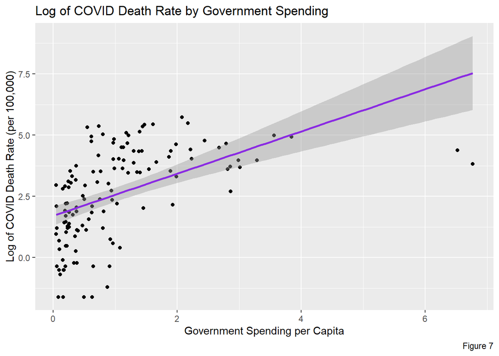

```r
ggplot(gov_data, aes(x = avg_sp_pc, y = log(mean_value))) +
  geom_point() +
  geom_smooth(method = "lm", color = "blueviolet") +
  labs(title = "Log of COVID Death Rate by Government Spending",
       caption = "Figure 7",
       x = "Government Spending per Capita",
       y = "Log of COVID Death Rate (per 100,000)")
```

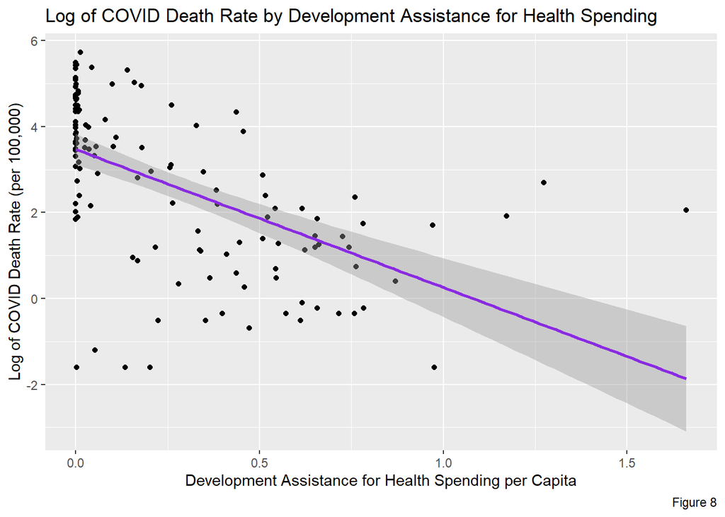

```r
ggplot(assist_data, aes(x = avg_sp_pc, y = log(mean_value))) +
  geom_point() +
  geom_smooth(method = "lm", color = "blueviolet") +
  labs(title = "Log of COVID Death Rate by Development Assistance for Health Spending",
       caption = "Figure 8",
       x = "Development Assistance for Health Spending per Capita",
       y = "Log of COVID Death Rate (per 100,000)")
```

These new models have lower p-values, 1.126e-09 for Government spending and 1.524e-11 for Development Assistance for Health, so they are clearly useful model. Additionally, we have significantly higher R-squared values for both models which can be clearly seen in the respective graphs. More importantly, the residuals for these models are much lower and seem to be normally distributed.

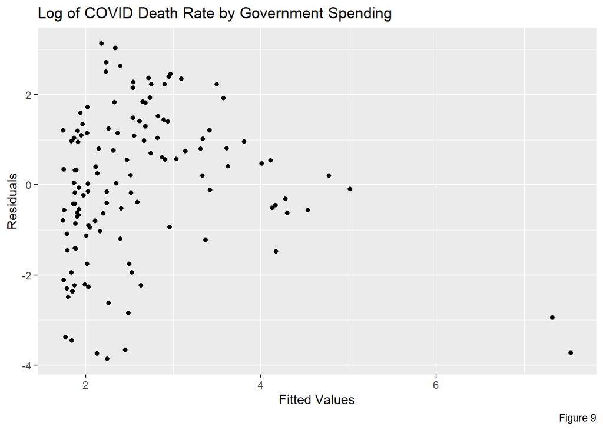

```r
ggplot(data = gov_log) +
  geom_jitter(aes(y = .resid, x = .fitted)) +
  labs(title = "Log of COVID Death Rate by Government Spending",
       caption = "Figure 9",
       x = "Fitted Values",
       y = "Residuals")
```

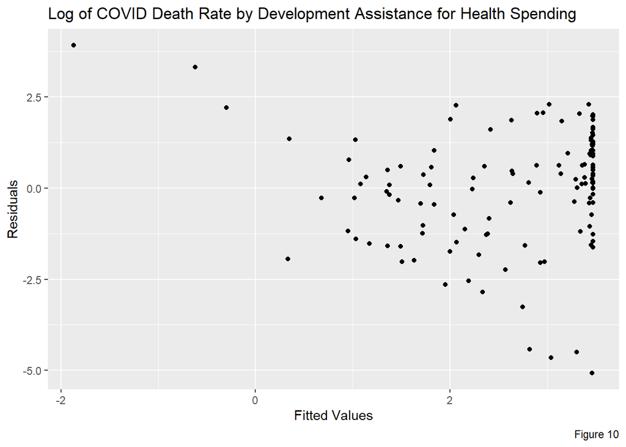

```r
ggplot(data = assist_log) +
  geom_jitter(aes(y = .resid, x = .fitted)) +
  labs(title = "Log of COVID Death Rate by Development Assistance for Health Spending",
       caption = "Figure 10",
       x = "Fitted Values",
       y = "Residuals")
```

Hence our statistical models indicate that Government spending and Development Assistance for Health spending are strongly correlated to COVID death rates. However this correlation is likely not linear and is more likely a logarithmic - or similar - correlation.

## Conclusion

In summary, by combining data on COVID deaths by country, spending on immunization in low to middle income countries from 2000-2017, and country populations during those same years, we have shown significant correlations between immunization spending and COVID death rates. Interestingly we found a positive correlation between a Government’s spending and their COVID death rate. More intuitively, Development Assistance for Heath spending had a negative correlation. We hesitate to draw significant conclusions from these correlations, since these are the reported COVID death rates so we cannot be completely confident that these are accurate. As a result we suspect that it is possible that immunization spending is more closely correlated with a country’s reporting of COVID deaths (or ability to identify COVID cases). For example, it is possible that high government spending isn’t correlated to high COVID death rates, but that low government spending is correlated with under reporting of COVID deaths. Similarly it is possible that under reporting countries are more likely to receive higher ammount of aid (Development Assistance for Health). This would be a interesting avenue for further study.